# 06_Proteomics

Nick Diercksen

Last compiled on 2023-03-30 18:43:00

```r
prot.full <- readxl::read_xlsx("./data/other omics/Proteome_all hits and first 500 hits.xlsx")
prot.top500 <- readxl::read_xlsx("./data/other omics/Proteome_all hits and first 500 hits.xlsx", sheet = "first 500 hits") %>%
  dplyr::rename("-log_pval" = "...2")
prot <- data.frame(prot.full[,1:6])
```

# Goal

Validate previous results of the DGSEA with the proteomics data. To look at the differential genes `t-test` or `ANOVA` can be used.

- how many genes are overlapping?

# examine proteomics data

## difference

calculate the mean difference between KO and WT (reconstruct previous analysis)

- remove this since, other metric (t-statistics) is more accurate

```r
prot500 <- prot.top500 %>%
  select("WT_1","WT_2","WT_3","KO_1","KO_2","KO_3", "Difference") %>%
  rowwise() %>%
  mutate(diff = sum(KO_1, KO_2, KO_3)/3 - sum(WT_1, WT_2, WT_3)/3) %>%
  ungroup()
```

## Sanity checks

- no `NA`s
- no zero counts

## PCA

All samples and proteins used (6) => no filtering was applied before in this analysis.

Goal: identify possible batch-effects

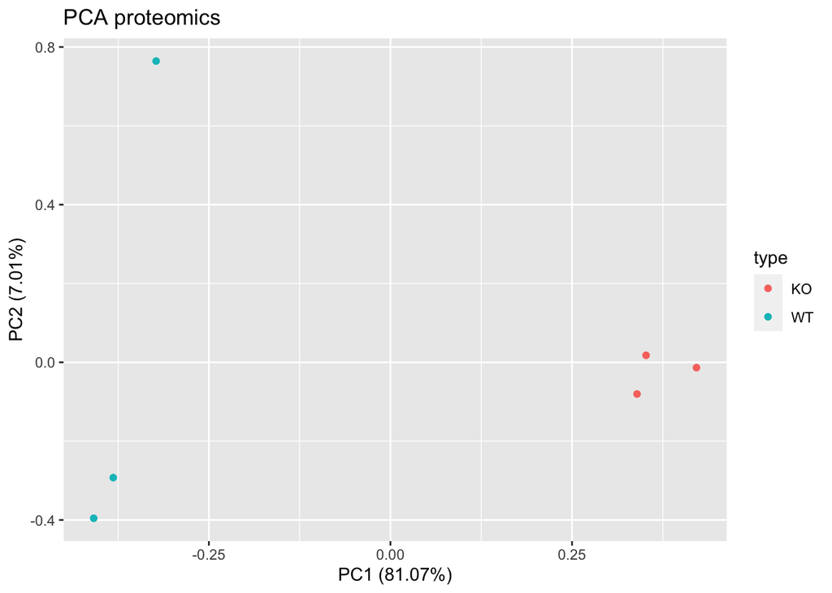

```r
pca <- prcomp(t(prot))

pca.data <- data.frame(Sample = rownames(pca$x),
                       X = pca$x[, 1],
                       Y = pca$x[, 2]) %>%
  mutate(type = substr(Sample, 1,2))

plt <-
  autoplot(
    pca,
    data = pca.data,
    colour = 'type',
    label.show.legend = FALSE
  ) +
  ggtitle("PCA proteomics")
# ggsave(filename = "./plots/04_pca_gastroc_filtered.png", plt, dpi=300)
plt
```

There is an outlier in the WT samples? WT and KO are still good separable.

# TODO

- t-test <-
- ANOVA

# t-test

## normalization and fitting

Before performing a “t-test” or similar analysis, the data needs to be normalized. Since it is not known whether a normalization of the data has not already been carried out, the first sample “WT_1” is examined:

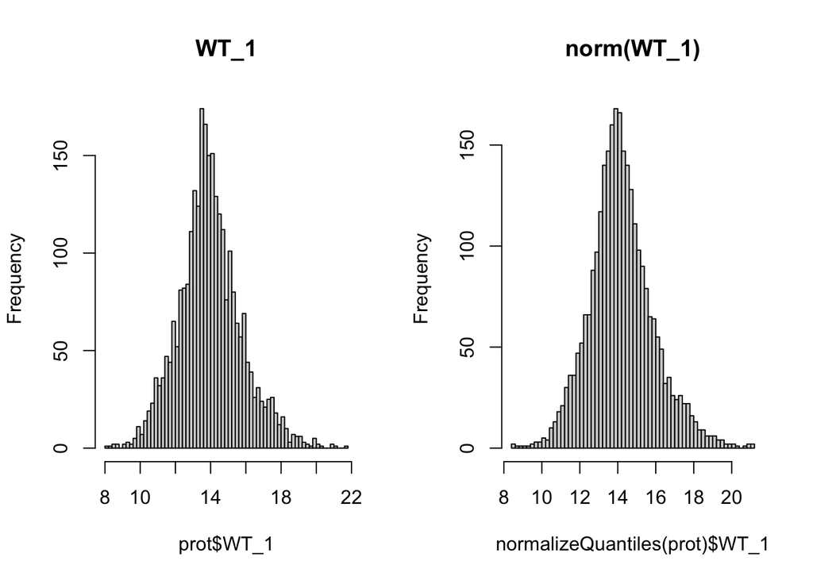

```r
par(mfrow = c(1, 2))
hist(prot$WT_1, breaks = 50, main = "WT_1")
hist(normalizeQuantiles(prot)$WT_1, breaks = 50, main="norm(WT_1)")
```

The first histogram seems to show that the data is already normally distributed.

However, the use of `normalizeQuantiles` seems to improve this, so this method will be used going forward.

To calculate the p-values, the `t.test()` is applied and the `Benjamini Hochberg` method is used to adjust them:

## p-values

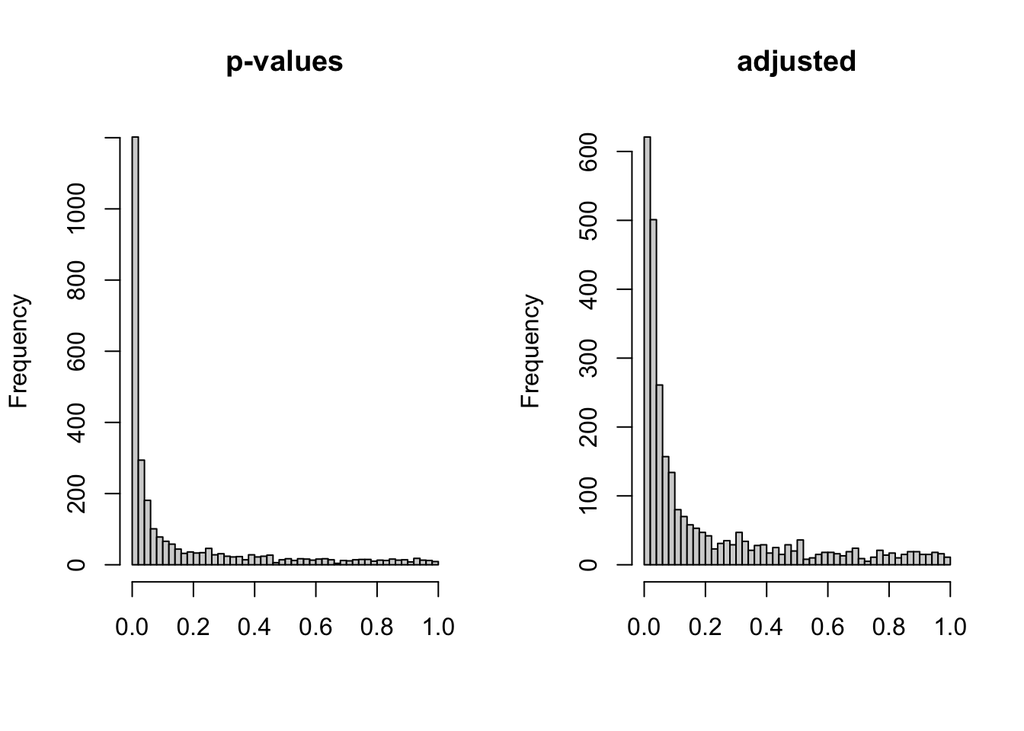

```r
# normalize
prot_normalized <- prot %>%
  limma::normalizeQuantiles()

t_stat_results <- apply(prot_normalized, 1, function(row) {
  result <- t.test(row[1:3], row[4:6])
  # c(statistic = result$statistic, p_value = result$p.value)
  c(statistic = result$statistic, p_value = result$p.value)
})

# Add t-statistics and p-values as new columns to the original data frame
prot_normalized <- cbind(prot_normalized, t(t_stat_results))

# adjust p-values
prot_normalized$padj <- p.adjust(prot_normalized$p_value, method = "BH")

par(mfrow = c(1, 2))
hist(prot_normalized$p_value, breaks = 50, main ="p-values", xlab = NA)
hist(prot_normalized$padj, breaks = 50, main = "adjusted", xlab = NA)
```

## fold change

```r
# calculate foldChange (without log)
prot_normalized <- prot_normalized %>%
  rowwise() %>%
  mutate(
    mean_WT        = mean(c(WT_1, WT_2, WT_3)),
    mean_KO        = mean(c(KO_1, KO_2, KO_3)),
    log2FoldChange     = log2(mean_KO / mean_WT)
  ) %>%
  ungroup() %>%
  mutate(genes = prot.full$`T: PG.Genes`)
```

## Volcano Plot

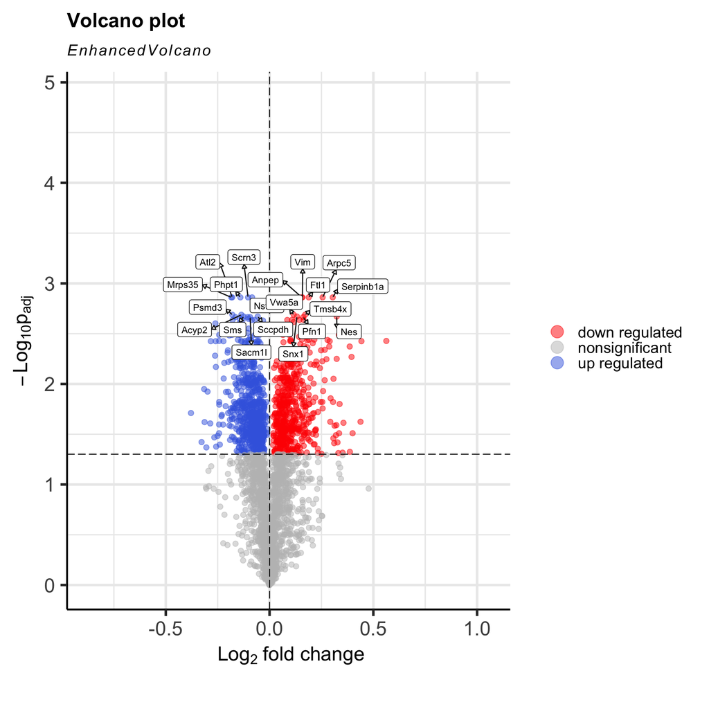

````r
#"```{r volcanoPlot, warning=FALSE, fig.width=4, fig.height=4}"
volcanoPlot <- function(result.df, pCutoff = 0.05, FCutoff = 0) {
  result.df <- result.df %>%
    dplyr::arrange(padj)

  # top 10 gene labels for respectively up and down regulation
  labs.up <- result.df[result.df$log2FoldChange > FCutoff,]$genes %>%
    .[1:10]
  labs.down <- result.df[result.df$log2FoldChange < -FCutoff, ]$genes %>%
    .[1:10]
  selectLab <- c(labs.up, labs.down)

  # custom colors:
  keyvals <- ifelse(
    result.df$log2FoldChange < -FCutoff &
      result.df$padj < pCutoff,
    params$regulated_pal$upregulated,
    ifelse(
      result.df$log2FoldChange > FCutoff &
        result.df$padj < pCutoff,
      params$regulated_pal$downregulated,
      params$regulated_pal$insignificant
    )
  )


  keyvals[is.na(keyvals)] <- params$regulated_pal$insignificant
  names(keyvals)[keyvals == params$regulated_pal$upregulated] <- 'up regulated'
  names(keyvals)[keyvals == params$regulated_pal$insignificant] <- 'nonsignificant'
  names(keyvals)[keyvals == params$regulated_pal$downregulated] <- 'down regulated'

  vlc.plt <- EnhancedVolcano(
    result.df,
    x = 'log2FoldChange',
    y = 'padj',
    # title = '',
    caption = "",
    ylab = expression(paste(-Log[10], p[adj])),
    pCutoff = pCutoff,
    FCcutoff = FCutoff,
    legendPosition = 'right',
    pointSize = 2,
    colCustom = keyvals,
    lab = result.df$genes,
    selectLab = selectLab,
    labSize = 3,
    boxedLabels = TRUE,
    drawConnectors = TRUE,
    max.overlaps = Inf,
    xlim = c(min(result.df[["log2FoldChange"]], na.rm = TRUE) - 0.5, max(result.df[["log2FoldChange"]], na.rm = TRUE) +
    0.5),
    ylim = c(0, max(-log10(result.df[["padj"]]), na.rm = TRUE) + 2),
  )

  return(vlc.plt)
}


volcanoPlot(prot_normalized, pCutoff = params$pCutoff, FCutoff = params$FCutoff)
````

- add labels for top fold change (over padj threshold)

### top differential expressed genes

```r
boxplot.top <- function(result.df, upregulated=TRUE, n = 20, FCutoff = 0) {
  # filter for up or down regulated proteins
  .filter <- ifelse(upregulated, `>`, `<`)
  result.df <- subset(result.df, .filter(log2FoldChange, FCutoff))

  # preparing top 20 (by `padj`) gene sets for ggplot function
  counts.plt <- result.df %>%
    dplyr::arrange(padj) %>%
    .[1:n,] %>%
    tidyr::pivot_longer(
      cols = WT_1:KO_3,
      names_to = "genotype",
      values_to = "counts",
      names_pattern = "^(..)" # first two characters of the column name ("WT", or "KO")
    ) %>%
    mutate(genotype = factor(genotype)) %>%
    mutate(genotype = relevel(genotype, "WT")) %>% # "WT" needs to be displayed before "KO"
    mutate(genes = forcats::fct_reorder(genes, counts, .desc = T))


  direction <- ifelse(upregulated, "up", "down")

  ggplot(counts.plt,
         aes(
           x = as.factor(genes),
           y = counts,
           fill = genotype
         )) +
    geom_dotplot(
      binaxis = 'y',
      stackdir = 'center',
      dotsize = 0.3,
      position = position_dodge(0.8),
      fill = "black"
    ) +
    geom_boxplot(outlier.size = 0.3) +
    scale_y_log10() +
    xlab("Genes") +
    ylab("expression level") +
    scale_fill_manual(values = params$condition_pal) +
    ggtitle(paste0("Top ", n, " ", direction, "-regulated Genes")) +
    theme_bw() +
    theme(plot.title = element_text(hjust = 0.5)) +
    theme(axis.text.x = element_text(
      angle = 45,
      hjust = 1,
    ))
}
```

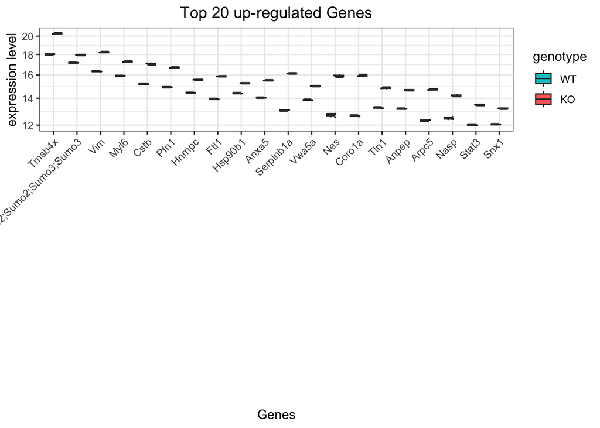

```r
boxplot.top(prot_normalized, upregulated = T)
```

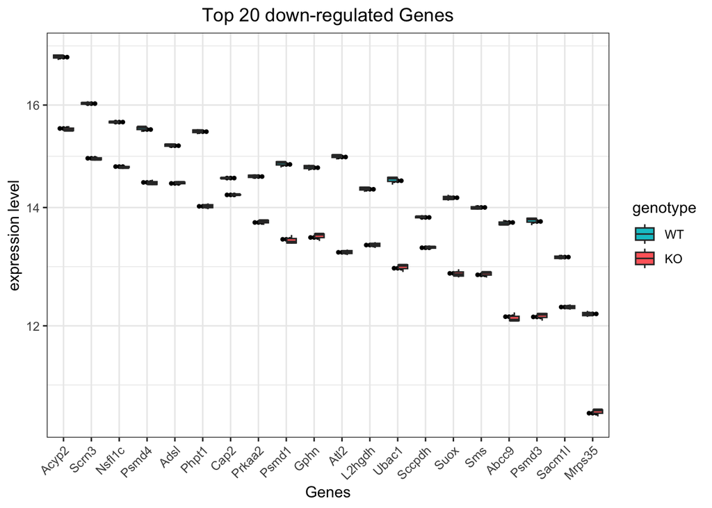

```r
boxplot.top(prot_normalized, upregulated = F)
```

# save R ojects

```r
save(prot_normalized, file = "./data/Robjects/06_Proteomics.RData")
```

# Questions

general - about the data:

- what metric are the values of the proteomics? Do you call them counts as well?
  - -> adjust names in this script!
- what tissue samples were used to produce the proteomics data?
  - was it produced using the combination of soleus and gastrocnemius tissues?
- it seems the gene “Nfe2l1” is not contained in this dataset (nor are his synonyms: NRF1, NFE2-related factor)
  - is there another synonym or protein group which is related?

analysis